# Usage-based AI exposure across Australia’s earnings distribution

Mapping US task-usage data onto ANZSCO occupations

Author

Luc Taya, Economics (Honours) graduate, University of Western Australia

**Important**

**Working paper v1.0, comments welcome.** Descriptive; not a job-loss or career-risk score; not advice.

## Abstract

Australian monitoring of generative AI relies on measures of what AI could do. This note asks where measured use sits in the earnings distribution. The usage data are task-level Claude.ai and first-party API use by self-selected users of one provider, classified to US O*NET tasks; no Australian occupational AI use is measured. I map Massenkoff and McCrory’s (2026) observed exposure onto 358 ANZSCO unit groups through official concordances, weight by Australian employment and rank units by earnings. Measured use is concentrated in higher-earning occupations: the concentration index is 0.089 and is positive in all 60 specifications reported. The gradient is modest and hump-shaped. Mean exposure is 0.069 in the bottom decile, peaks at 0.192 in decile 7 and is 0.111 in the top decile; the bottom-to-top difference depends on single units and changes sign under one of four crosswalks. Whether any linked task shows measured use, the extensive margin, accounts for more than the whole bottom-to-top difference. Ranked against capability measures, measured use places low earners’ occupations higher and high earners’ lower; against Jobs and Skills Australia’s automation scores it places the top quintile higher. Women’s occupations show more measured use than men’s in every earnings decile, and Western Australia’s occupation mix lowers its mean by 11 per cent. Three checks qualify these results. Under simulated crosswalk and earnings uncertainty the concentration index stays positive in every draw, but the decile-7 peak does not. Microsoft’s Copilot-based measure of AI applicability, mapped the same way, is not concentrated among higher earners under the main earnings ranking, so part of the gradient may be specific to Claude’s users. And across occupations, the earnings gradient in measured use all but disappears once teleworkability is held fixed: measured use follows whether work runs through a computer more closely than it follows pay. Nothing here measures how Australian workers use AI.

*JEL:* J24, J31, O33. *Keywords:* generative AI; occupational exposure; earnings distribution; crosswalks; Australia.

**Key findings**

1. **Concentration is robust within these data.** The concentration index of usage-based exposure is 0.089 and is positive in all 60 specifications (0.028 to 0.213) and in every one of 500 simulated draws of crosswalk weights and earnings. A rank-based index, comparable across measures, is positive in all of them too.
2. **The shape is not.** Exposure rises from 0.069 in the bottom decile to a peak of 0.192 in decile 7 and is 0.111 at the top. The bottom-to-top difference of 4.3 points ranges from 2.5 to 6.9 when single large units are left out and is negative under the crosswalk built on JSA’s direct correspondence; the decile-7 peak survives in 41% of simulated draws.
3. **The gradient runs through the extensive margin.** The share of linked US occupations with any measured use rises from 0.39 to 0.81; use conditional on any use is lower at the top than at the bottom.
4. **Measured use sits between two families of potential measures.** On a rank basis it is less concentrated among high earners than capability measures (JSA augmentation, Eloundou et al.’s beta, AIOE) and more concentrated than JSA’s automation scores.
5. **It may partly be Claude, and it follows computer work.** On Copilot-based applicability, mapped the same way, the rank concentration index is −0.011 under the main ranking, against 0.073 for Claude usage; it is positive in 48 of 60 specifications, all of them under the alternative earnings rankings. Across occupations, the slope of usage rank on earnings rank falls from 0.22 to 0.01 once teleworkability is held fixed.
6. **Composition.** Women’s occupations show more measured use than men’s in every decile (0.142 against 0.100). WA’s occupation mix lowers its mean by 1.4 points (11 per cent).

**What this note is not.** It is descriptive. Scores describe US occupations’ tasks and are applied to Australia’s occupation mix, so every comparison is between occupations, not within them. Every result is shown beside a measure that does not come from Anthropic, except the conversation shares in Section 4.8.

## 1 Introduction

Australia monitors generative AI through measures of potential. Jobs and Skills Australia (JSA, 2025) scores every ANZSCO unit group for how far generative AI could automate or augment its tasks. The Department of Employment and Workplace Relations (DEWR, 2026) uses the automation scores to ask whether exposed occupations have grown more slowly since ChatGPT’s release: employment in the most exposed fifth of occupations grew 5.6 per cent between November 2022 and February 2026, against 9.5 per cent in the least exposed fifth. With Massenkoff and McCrory’s observed exposure in place of JSA’s scores, DEWR’s estimate is near zero and not significant (Department of Employment and Workplace Relations 2026, 52). Single Touch Payroll data show the weakest hiring in clerical and administrative occupations (Gross 2026). What these measures cannot say is where AI is actually used. That is a prior question for monitoring, and for distributional questions such as how AI-driven wage changes would fall across the tax base, where current scenarios assume an even spread across the income distribution (Nolan and Rankin 2026).

This note maps a usage-based measure onto Australian occupations and asks two questions. How is measured use distributed across Australia’s earnings distribution? And where does it rank occupations higher or lower than measures of potential do? The usage measure is Massenkoff and McCrory’s (2026) observed exposure: the time-weighted share of an occupation’s tasks that pass a capability gate and show sufficient work-related use of Claude. I link its 756 US occupations to the 358 ANZSCO v1.2 unit groups through BLS and ABS concordances (355 of them receive a score), grade every unit by how many US occupations feed it, run four weighting schemes and report every specification, including those that fail rules fixed before results were produced.

Four findings stand out. First, measured use is concentrated among higher earners. The concentration index is 0.089 in the main specification and positive in all 60 specifications. Second, the gradient is modest and hump-shaped: mean exposure rises from 0.069 in the bottom decile to 0.192 in decile 7 and falls to 0.111 in the top decile. That shape is consistent with Handa et al.’s (2025) finding that Claude use peaks in occupations in the upper wage quartile and is lower at both extremes, but in these data the shape itself is fragile: leaving single large units out moves the bottom-to-top difference between 2.5 and 6.9 points, and it is negative under the crosswalk built on JSA’s direct correspondence. Third, the gradient runs through the extensive margin. The share of linked US occupations with any measured use rises from 0.39 to 0.81 between the bottom and top deciles, while use conditional on any use is lower at the top. Fourth, on a rank basis measured use is less concentrated among high earners than capability-based measures (JSA’s augmentation scores, Eloundou et al.’s (2024) beta and Felten et al.’s (2021) AIOE): it ranks the bottom quintile’s occupations higher and the top quintile’s lower than they do, under every scheme. Relative to JSA’s automation scores, the primary comparator, it ranks the top quintile higher under every scheme; the bottom-quintile comparison is not robust. Two composition results follow: women’s occupations show more measured use than men’s in every earnings decile, and Western Australia’s occupation mix lowers its mean by 11 per cent.

Three checks added for this version qualify the first finding. Simulating uncertainty in the crosswalk weights and in published earnings leaves the concentration index positive in every draw but moves the peak away from decile 7 in most draws. Running Microsoft’s Copilot-based applicability scores (Tomlinson et al. 2025) through the same crosswalk gives a measure that is positively rank-correlated with Claude usage across occupations (0.65) but not concentrated among higher earners under the main earnings ranking. And holding teleworkability (Dingel and Neiman 2020) fixed, measured use no longer rises with earnings across occupations, which matches Levkoff’s (2026) US finding that whether work runs through a computer predicts use better than wages do.

The note joins three literatures. The first measures AI use from platform logs (Handa et al. 2025; Tomlinson et al. 2025; Chatterji et al. 2025; Massenkoff and McCrory 2026). In US data, workers in the most exposed quarter of occupations earn 47 per cent more than workers with zero exposure (Massenkoff and McCrory 2026). Within the capability envelope, however, whether work already runs through a computer predicts use better than wages do (Levkoff 2026), and Copilot-based applicability is only weakly correlated with occupational wages (Tomlinson et al. 2025). Platform logs also reflect who uses each platform: changing only the platform input moves estimated employment effects by a factor of 1.9, and Claude.ai and Anthropic’s first-party API give coefficients of opposite sign (Yin and Ogut 2026). That caveat applies with force here. The second literature maps US exposure measures onto other countries’ occupational structures (Pizzinelli et al. 2023; Cazzaniga et al. 2024; Gmyrek et al. 2025; Murugan et al. 2026). Through occupational composition, women are more exposed than men in 126 of 138 countries (Murugan et al. 2026), and US task content applies imperfectly abroad (Lewandowski et al. 2022). The third concerns Australia: technological change and earnings inequality (Coelli and Borland 2016; Borland and Coelli 2017), the potential-based monitoring above, and two uses of Anthropic data with ANZSCO. DEWR (2026) uses observed exposure as an alternative measure in its employment model, and Demirev (2026) maps an earlier usage score through three-digit ISCO to study job postings. Neither examines earnings.

## 2 Data

### 2.1 Usage-based exposure

Massenkoff and McCrory (2026) publish observed exposure for 756 six-digit SOC 2018 occupations, as `job_exposure.csv` in the Anthropic Economic Index dataset (Massenkoff et al. 2026). Usage comes from the August and November 2025 Economic Index samples: work-related Claude.ai conversations and first-party API traffic, classified to US O*NET tasks. A task is covered if its work-related usage passes a fixed threshold and its Eloundou et al. beta is positive. Covered tasks are weighted by a factor that runs from one half (augmentative use only) to one (automated use only), and the occupation score is the time-fraction-weighted sum over its tasks, with time fractions from earlier Anthropic work. Of the 756 scores, 411 (54%) are exactly zero; the unweighted mean is 0.077 and the maximum 0.745 (Computer Programmers). Weighted by US employment (OEWS, May 2025), the mean is 0.131, and 40% of US employment in scored occupations is at exactly zero. The other 111 of the 867 detailed SOC occupations have no score and are treated as missing, not zero.

A zero means that an occupation’s tasks fell below the usage threshold in Anthropic’s samples, or that none of its used tasks passed the capability gate. It does not mean no use. Zeros are flagged wherever unit values appear.

### 2.2 Australian usage composition

For Section 4.8 I use the 2026-06-26 release of the Economic Index geography file: Claude.ai conversations in April and May 2026, with 11,629 rows for Australia and 1,172 for Western Australia. Detailed SOC rows for countries and subregions are published only as shares of conversations, and collaboration measures only at SOC major-group level. Missing rows are suppressed cells, not zeros. The rows classify the task in a conversation, not the user’s job.

### 2.3 Potential exposure

Three families of comparison measures use no Claude data. JSA’s automation and augmentation scores cover 357 ANZSCO unit groups. JSA built them by adapting the method of Gmyrek et al. (2023) to Australian occupations’ tasks, with separate scores for tasks generative AI could undertake (automation) or assist with (augmentation) (Jobs and Skills Australia 2025); DEWR (2026, Appendix A) describes the task scoring as a judgement by a large language model. Being native to ANZSCO, they need no crosswalk, and the automation scores are the measure DEWR uses for monitoring; JSA automation is therefore the primary comparator. Eloundou et al.’s beta, rated against early-2023 capabilities by GPT-4, is averaged from O*NET occupations to SOC codes. JSA’s scores and beta both rest on language-model ratings of tasks, and observed exposure is gated on beta, so comparisons with beta are partly mechanical. Felten et al.’s AIOE (the original 2021 version, not the language-model variant) links AI applications to occupational abilities through a survey and shares no inputs with the other measures. Its repository states no licence, so it appears only in aggregate statistics.

### 2.4 Employment and earnings

Employment weights come from ABS Labour Force table EQ08 (Australian Bureau of Statistics 2026b), which gives employed persons by ANZSCO v1.2 unit group, sex and state each quarter. I average the 4 quarters from May 2025 to February 2026: 14.67 million employed, 1.66 million of them in Western Australia. EQ08 is not published from April 2026 (Australian Bureau of Statistics 2026d), and Labour Force occupation data are coded to OSCA from the September 2026 reference period (Australian Bureau of Statistics 2026c).

Units are ranked by average weekly total cash earnings of all employees in the ABS Employee Earnings and Hours survey, May 2025, data cube 11 (Australian Bureau of Statistics 2026a). No EEH cube gives hourly earnings at unit-group level. Two alternative rankings appear in the appendix: average hourly total cash earnings of full-time non-managerial adult employees (EEH cube 13, three-digit minor groups only, so the 3 chief executive, general manager and legislator units have no value) and average salary or wage income from ATO Taxation Statistics 2023–24, Table 15B (Australian Taxation Office, n.d.). EEH excludes owner-managers, whom EQ08 counts.

### 2.5 Crosswalks

US occupations are linked to ANZSCO through SOC 2018 → SOC 2010 → ISCO-08 (BLS concordances) → ANZSCO v1.2 (ABS concordance). A fourth weighting scheme uses JSA’s direct correspondence from ANZSCO v1.2 to O*NET-SOC 2019 (Jobs and Skills Australia 2024). Within each unit, US occupations are weighted by May 2025 OEWS employment (U.S. Bureau of Labor Statistics, n.d.). Every file’s source, access date, checksum and licence is recorded in `data/raw/MANIFEST.csv`.

## 3 Methods

**Main specification.** Weighting scheme 1, all unit groups, EEH weekly earnings and JSA automation as the primary comparator. Each choice was set before any result was produced and recorded in `decision_log.md`. Every alternative is in the appendix.

### 3.1 Edition spine

The unit of analysis is the ANZSCO v1.2 unit group (358 units), the only edition with employment by sex and state. Employment coded “not further defined” (1.8% to 2.6% of each quarter) is shared among the unit groups beneath it in proportion to their employment in the same quarter, sex and state. ANZSCO v1.3 has the same codes as v1.2. EEH and ATO data, coded to ANZSCO 2021 and 2022, are bridged back through ABS correspondences: of 369 unit-to-unit links, 337 keep their code, 5 are recoded, 14 merge several units, 7 split one unit and 6 are many-to-many. A merged unit takes the ATO-count-weighted mean of its sources; a split unit passes its value to each child. The 19 units without a published EEH value take the employment-weighted mean of their minor group; each is listed in the appendix.

### 3.2 Usage-based exposure for each unit

The usage-based exposure of unit $a$ is
$$e_a = \sum_{s \in S_a} w_{as}\, e_s, \qquad \sum_{s \in S_a} w_{as} = 1,$$
where $S_a$ is the set of linked US occupations with a score and the weights are renormalised over that set. Renormalising assigns unscored US occupations the mean of the scored ones in the same unit. This matters where unscored occupations dominate: Aged and Disabled Carers takes its value from two supervisory occupations because its main counterparts, Home Health Aides and Personal Care Aides, have no score. A lower bound that counts unscored links as zero is reported alongside. The extensive margin applies the same weights to an indicator of any measured use, $m_a = \sum_s w_{as}\mathbf{1}[e_s > 0]$, and intensity is $i_a = e_a/m_a$. As a capability analogue that uses no Claude data, the same weights applied to $\mathbf{1}[\beta_s > 0]$ give the share of linked US occupations that any language model could assist.

Four weighting schemes give four versions of every unit value: scheme 1, US employment weights on the primary chain (main); scheme 2, equal weights on the same links; scheme 3, title-match-first, which keeps only the US occupations whose titles match an ANZSCO occupation’s title, where any match (titles match when their word sets are equal or their Jaccard similarity is at least 0.75; 150 occupations in 81 units match); and scheme 4, JSA’s correspondence links with US employment weights (354 units have links, 347 of them a scored link).

The primary chain has 2,438 unit-to-occupation links through 429 ISCO-08 units. Because ISCO-08 is coarser than both SOC and ANZSCO, the chain averages zeros with positive scores: 40% of US employment in scored occupations is at zero, but units with exactly zero exposure hold only 13.7% of Australian employment. Every unit is therefore graded by how many US occupations feed it (Table 1) and carries the share of its linked US employment that is unscored; 25 units, with 5.9% of employment, have a majority unscored. A second chain through the ANZSCO 2022 correspondence gives identical links for 350 units and different links for 8. Coverage, the share of employment in units with at least one scored link, is 99.1% against a target of 98% set in advance; the main omission is Education Aides.

Table 1: Crosswalk grades.

| Grade | Linked US occupations | Units | Share of employment |
| --- | --- | --- | --- |
| One-to-one | one | 59 | 13.5% |
| Few-to-one | two to four | 155 | 47.1% |
| Diffuse | five or more | 141 | 38.5% |

### 3.3 Earnings deciles and concentration

Units are ranked by earnings and cut into employment-weighted deciles; a unit straddling a boundary is split in proportion. A unit’s earnings rank is the mid-point of its block of cumulative employment. Decile means are employment-weighted, and decile intensity is mean exposure divided by mean extensive margin. Differences in exposure are reported in exposure points (exposure × 100), computed from unrounded values; differences in ranks are in percentile points.

The concentration index is $CI = 2\,\mathrm{cov}_w(e, r)/\bar{e}$, where $r$ is the employment-weighted fractional earnings rank and $\bar{e}$ the employment-weighted mean. A positive index means exposure is concentrated among higher earners. The level index scales with each measure’s mean and dispersion, so it does not compare measures. For comparisons across measures I use the rank index $CI_R = 4\,\mathrm{cov}_w(R_m, r)$, where $R_m$ is the employment-weighted rank of measure $m$; without ties it equals one third of the weighted Spearman correlation between the measure and earnings. For measures bounded between zero and one I also report the Erreygers index $4\bar{e}\,CI$ (Erreygers 2009). The rank and Erreygers indices were added after the first results.

### 3.4 Usage against potential

For each unit, the usage-potential gap is the employment-weighted percentile rank of usage-based exposure minus that of the potential measure, averaged within deciles or quintiles with employment weights. Two properties govern how it reads. Because both ranks average fifty over employment, the gaps average zero: the profile shows where usage ranks occupations relatively higher or lower, not whether use runs ahead of potential in any absolute sense. And all units with zero exposure share one mid-rank (about 7), so a zero unit’s gap is set by its potential rank alone. Gaps with zero units left out are reported alongside.

### 3.5 Women and men, Western Australia and occupation groups

Deciles for women and men come from the persons earnings ranking; within each decile, exposure is averaged with each sex’s employment. The difference between women and men is split into a within-decile part (women and men in the same decile work in different occupations) and a between-decile part (they are spread differently across deciles), using average shares so the parts add up. The difference between WA and national mean exposure is
$$\Delta = \sum_a \left(s^{WA}_a - s^{AUS}_a\right) e_a,$$
where $s$ are employment shares. Because every unit carries one national value, $\Delta$ reflects occupation mix only. Major-group contributions are measured relative to the national mean, $C_g = \sum_{a\in g}(s^{WA}_a - s^{AUS}_a)(e_a - \bar{e}^{AUS})$, so they do not depend on the level of $e$ (Oaxaca and Ransom 1999; Yun 2005). For usage by occupation group, each SOC major group’s share of Claude.ai conversations is divided by its share of employment, as in Handa et al. (2025). Australian and WA employment is EQ08 allocated to SOC groups with scheme 1 weights; the global row uses US OEWS employment, as no global employment by SOC exists.

### 3.6 What counts as holding

These rules were fixed before any results were produced. A decile profile holds under a variant if its OLS slope across deciles has the main profile’s sign and the Spearman correlation of the two sets of decile means is at least 0.7. The usage-potential gap holds if its sign in the top and bottom quintiles is the same under every weighting scheme. Summaries added after the first results are labelled as such: the sign of the concentration indices across specifications, the influence of single units, the lower bound for unscored links and the gaps without zero units.

## 4 Results

### 4.1 Measured use across the earnings distribution

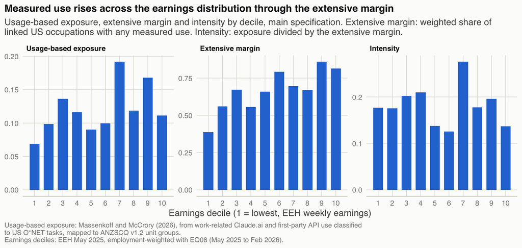

Figure 1: Usage-based exposure, extensive margin and intensity by earnings decile, main specification.

Mean usage-based exposure is 0.069 in the bottom decile and 0.111 in the top, a difference of 4.3 points (Figure 1). The profile is hump-shaped rather than monotone: it peaks at 0.192 in decile 7 and is high again in decile 9 (0.168). A smoothed profile over earnings percentiles, which does not depend on decile boundaries, also peaks in the upper-middle of the distribution (appendix). This is consistent with the US pattern in Claude data, where use peaks in the upper wage quartile and is lower at both extremes (Handa et al. 2025), and it peaks lower in the distribution than Webb’s (2020) patent-based measure, which is highest at about the ninetieth wage percentile.

The extensive margin rises from 0.39 to 0.81 (Table 2). Intensity varies between 0.13 and 0.28 with no monotone pattern and is lower in the top decile than in the bottom. In logs, the extensive margin accounts for 153 per cent of the bottom-to-top difference and intensity for −53 per cent. Across the earnings distribution, measured use differs mainly in whether linked tasks show any use at all, not in how heavily they are used. Both the usage threshold and the crosswalk shape this margin: in units fed by four or fewer US occupations, bottom-decile exposure is 0.025 rather than 0.069 (Section 5). The capability analogue rises far less: the share of linked US occupations with a positive beta is 0.87 in the bottom decile and 0.97 in the top.

Table 2: The bottom-to-top difference runs through the extensive margin. Main specification; $\ln(e_{10}/e_1)=\ln(m_{10}/m_1)+\ln(i_{10}/i_1)$, computed from unrounded decile means.

|  | Decile 1 | Decile 10 | Log difference | Share of total (%) |
| --- | --- | --- | --- | --- |
| Usage-based exposure $e$ | 0.069 | 0.111 | 0.484 | 100 |
| Extensive margin $m$ | 0.388 | 0.814 | 0.742 | 153 |
| Intensity $e/m$ | 0.177 | 0.137 | −0.258 | −53 |

### 4.2 Concentration

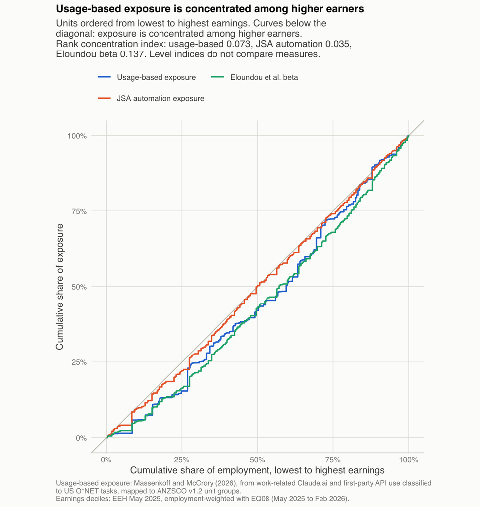

Figure 2: Concentration curves, units ordered from lowest to highest earnings.

The concentration index of usage-based exposure is 0.089 (Figure 2). It is positive in each of the 60 specifications in the appendix, from 0.028 to 0.213 (Figure 8), and so is the rank index (0.043 to 0.150). Because it summarises the whole distribution, it depends less on single deciles than the top-minus-bottom difference does.

The measures are compared on ranks (Table 3). Usage-based exposure (0.073) is more concentrated among high earners than JSA automation (0.035), and less than JSA augmentation (0.147), beta (0.137) and AIOE (0.141). The Erreygers indices order the bounded measures the same way. The level indices do not: JSA augmentation’s level index (0.037) is below usage’s because its mean is high relative to its spread, not because it is less related to earnings.

Table 3: Concentration among higher earners, by measure. Main specification, EEH weekly ranking. The level index does not compare measures; the rank and Erreygers indices do. AIOE takes negative values, so only its rank index is defined. Rank and Erreygers indices added after the first results.

| Measure | Mean | Level index | Rank index | Erreygers index |
| --- | --- | --- | --- | --- |
| Usage-based exposure | 0.120 | 0.089 | 0.073 | 0.043 |
| JSA automation (primary) | 0.373 | 0.013 | 0.035 | 0.020 |
| JSA augmentation | 0.635 | 0.037 | 0.147 | 0.094 |
| Eloundou et al. beta | 0.360 | 0.116 | 0.137 | 0.167 |
| AIOE |  |  | 0.141 |  |

### 4.3 Measured use relative to potential

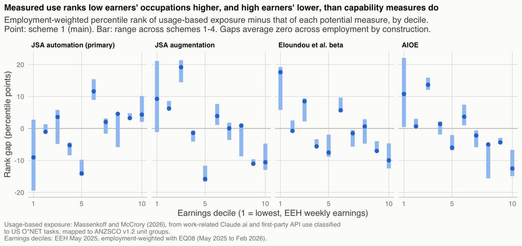

Figure 3: Usage-potential rank gap by earnings decile.

Against the primary comparator, JSA automation, usage-based exposure ranks the top earnings quintile’s occupations 3.8 points higher, and the sign holds under all four schemes (Table 4). It ranks the bottom quintile’s occupations 5.1 points lower under scheme 1, but 1.6 points higher under scheme 4, so the bottom-quintile result fails the rule. Against the capability family the pattern reverses and is robust. Relative to JSA augmentation, beta and AIOE, usage ranks the bottom quintile 7.7, 8.4 and 5.7 points higher and the top quintile 10.8, 8.5 and 8.5 points lower, with both signs stable across schemes. AIOE shares no inputs with observed exposure, so the pattern is not an artefact of the capability gate; consistent with that, AIOE’s rank correlation with usage (0.79) is as high as beta’s (0.77). Leaving out zero-exposure units, whose shared rank sets their gaps, keeps every sign (appendix).

Measured use therefore sits between the two families: more concentrated among high earners than JSA’s automation potential, less concentrated than capability measures. Decile-level gaps are noisy (the scheme range against JSA automation in decile 1 spans 22 points), and because the gaps average zero, a positive gap at the bottom implies negative gaps elsewhere.

Table 4: Usage-potential rank gap in the bottom and top earnings quintiles. Mean rank gap in percentile points, EEH weekly ranking, all units. Only the bottom-quintile gap against JSA automation changes sign across schemes, so it fails the rule; all other signs hold.

| Potential measure | Scheme 1: Bottom | Scheme 1: Top | Scheme 2: Bottom | Scheme 2: Top | Scheme 3: Bottom | Scheme 3: Top | Scheme 4: Bottom | Scheme 4: Top |
| --- | --- | --- | --- | --- | --- | --- | --- | --- |
| JSA automation (primary) | −5.1 | 3.8 | −9.1 | 7.4 | −4.1 | 2.9 | 1.6 | 4.0 |
| JSA augmentation | 7.7 | −10.8 | 3.7 | −7.2 | 8.8 | −11.8 | 14.7 | −11.0 |
| Eloundou et al. beta | 8.4 | −8.5 | 2.8 | −4.8 | 8.8 | −9.5 | 10.9 | −7.7 |
| AIOE | 5.7 | −8.5 | 1.7 | −4.8 | 6.7 | −9.5 | 12.1 | −8.7 |

### 4.4 Earnings, capability and computer work

Two readings fit a positive concentration index. In one, use follows pay: the value of time saved rises with the wage. In the other, use follows whether work already runs through a computer, which is more common in better-paid occupations. To separate them, Table 5 regresses each unit’s employment-weighted percentile rank on usage-based exposure on its earnings rank, with employment weights, adding a potential measure and Dingel and Neiman’s (2020) teleworkability classification, mapped through the same crosswalk. The 352 units with every measure are used.

Table 5: Measured use rises with earnings across occupations only until teleworkability is held fixed. Coefficients from employment-weighted regressions of the unit’s percentile rank on usage-based exposure on percentile ranks of the variables shown (HC1 standard errors in brackets). Main specification. Descriptive partial associations, not effects. Added after the first results.

| Controls | Earnings rank | Teleworkability rank | Potential-measure rank |
| --- | --- | --- | --- |
| None | 0.22 (0.09) |  |  |
| Teleworkability | 0.01 (0.08) | 0.63 (0.07) |  |
| JSA automation | 0.15 (0.05) |  | 0.70 (0.05) |
| JSA automation, teleworkability | 0.07 (0.06) | 0.27 (0.08) | 0.55 (0.08) |
| JSA augmentation, teleworkability | −0.11 (0.08) | 0.40 (0.09) | 0.45 (0.08) |
| Eloundou et al. beta, teleworkability | −0.13 (0.07) | 0.19 (0.08) | 0.69 (0.07) |
| AIOE, teleworkability | −0.14 (0.07) | 0.01 (0.08) | 0.84 (0.07) |

Without controls, a unit’s usage rank rises by 0.22 percentile points for each point of earnings rank (standard error 0.09). Teleworkability is correlated with earnings rank (0.35) and more strongly with usage rank (0.62), and holding it fixed reduces the earnings slope to 0.01 (0.08). Holding JSA automation and teleworkability fixed leaves 0.07 (0.06); in the decomposition of Gelbach (2016), teleworkability accounts for 0.09 of the fall and JSA automation for 0.06. Holding a capability measure fixed instead (JSA augmentation, beta or AIOE), the earnings slope turns negative, between −0.14 and −0.11: among occupations that capability measures rate alike, measured use is if anything lower in better-paid ones, as the rank gaps in Section 4.3 suggest. Treating JSA augmentation and AIOE as two noisy measures of the same capability, and instrumenting each with the other (Gillen et al. 2019), gives −0.27. The extensive margin behaves the same way: its earnings slope of 0.26 falls to 0.06 with teleworkability held fixed.

Across Australian occupations, then, measured use tracks computer-based work and capability more closely than pay. These are partial associations across 352 occupations: teleworkability and earnings are correlated, neither is assigned, and teleworkability is itself measured from US task descriptions.

### 4.5 Where usage and JSA automation disagree

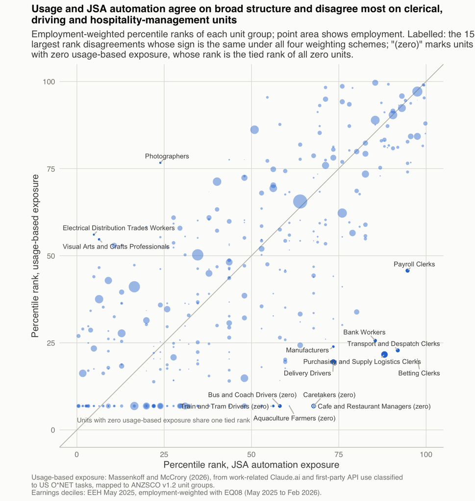

Figure 4: Usage-based exposure against JSA automation exposure, by unit group.

Across units, usage-based exposure and JSA automation are positively rank-correlated (0.72, employment-weighted; Figure 4). Of the 15 largest disagreements whose sign holds under every scheme, 12 are units that usage ranks below JSA: clerical units (betting, transport and despatch, purchasing and supply logistics, bank workers, payroll), driving units (delivery, bus and coach, train and tram) and hospitality management. Five of them have exactly zero exposure, so their rank is the tied rank and their gap is set by JSA alone. The three units usage ranks above JSA are photographers, visual arts and crafts professionals and electrical distribution trades workers; the last falls from 51 to 11 points under the JSA correspondence. Ranked instead by their contribution to employment-weighted gaps, the largest disagreements are larger units (appendix).

The clerical disagreements matter for monitoring. Australian payroll data show the weakest hiring since ChatGPT’s release in clerical and administrative occupations, among them accounting, payroll and general clerks (Gross 2026), yet usage-based exposure ranks payroll clerks 49 points below JSA. One reading is that much clerical automation runs through enterprise software rather than chat interfaces, which conversation logs see poorly. On this evidence, usage-based and potential measures complement each other in monitoring; neither substitutes for the other.

### 4.6 Women and men

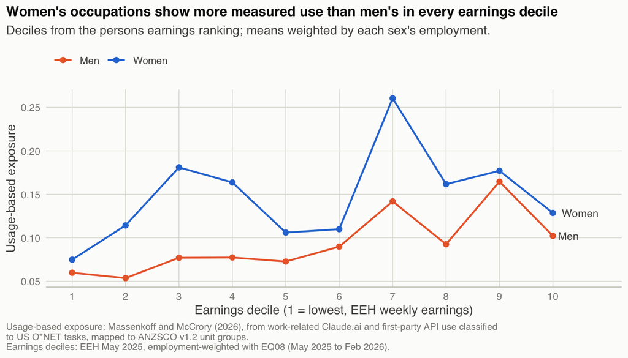

Figure 5: Usage-based exposure of women and men by earnings decile.

Women’s employment-weighted usage-based exposure is 0.142 and men’s 0.100, and women’s is higher in all 10 deciles (Figure 5). Differences within deciles account for 128 per cent of the gap; women’s lower position in the earnings distribution offsets the rest. JSA automation gives the same ordering (0.404 against 0.346), and JSA reports women as marginally more exposed on both of its measures (Jobs and Skills Australia 2025). Through occupational composition, women are more exposed than men in most countries on potential measures (Murugan et al. 2026). By construction, the gap here reflects the occupations women and men work in, not differences in use within occupations. Survey evidence points the other way within occupations. Danish women were 16 percentage points less likely than men in the same occupation to use ChatGPT (Humlum and Vestergaard 2025), and in Anthropic’s sample of Claude users linked to a survey, women’s automation share is 7.3 points lower conditional on occupation (Massenkoff et al. 2026). Exposure measured by occupation and use measured by person can move in opposite directions.

### 4.7 Western Australia

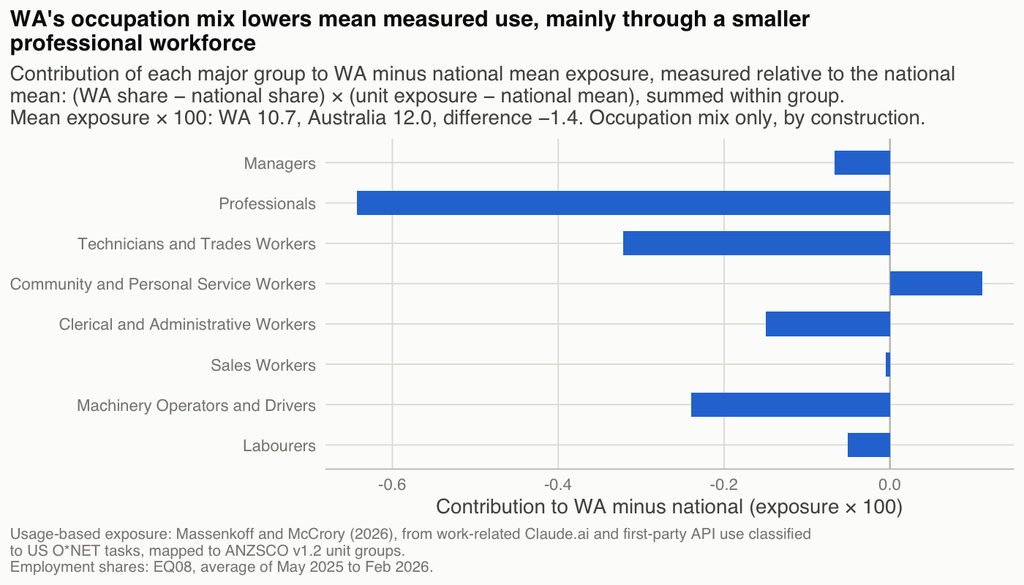

Figure 6: Contribution of each major group to WA minus national mean exposure, measured relative to the national mean.

WA’s mean usage-based exposure is 0.107 against 0.120 nationally: 1.4 points, or 11 per cent, lower (Figure 6). By construction the difference is occupation mix only. The potential measures show smaller relative gaps: 3 per cent for JSA automation and 5 per cent for beta. Professionals contribute most: they are 25.2% of WA employment against 27.8% nationally, and their contribution measured relative to the national mean is −0.64 points. On that measure WA’s larger shares of trades workers and machinery operators also lower its mean (−0.32 and −0.24).

Anthropic’s data offer context. In February 2026, WA’s Claude use per working-age person was well below the national rate (a state usage index of 0.68), which Anthropic attributes, hedged as “likely”, to WA and the Northern Territory having smaller shares of workers in occupations where Claude is commonly adopted (McCrory 2026). The two numbers measure different things (conversation volume per person against task coverage by occupation), so they cannot be divided into a share explained. Both point the same way.

### 4.8 Usage relative to employment by occupation group

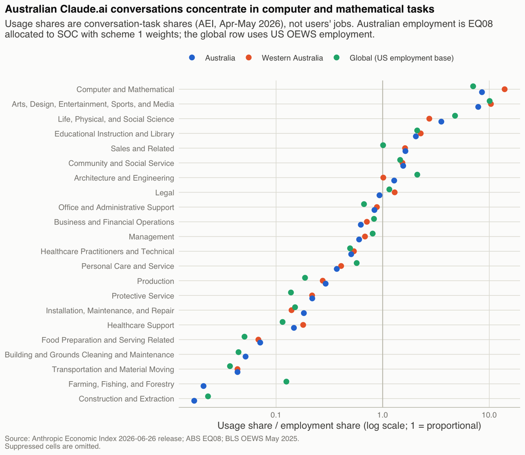

Figure 7: Claude.ai conversation share divided by employment share for each SOC major group, for Australia, Western Australia and the global sample.

Relative to employment, Australian conversations are most concentrated in Computer and Mathematical tasks (8.5 times their employment share) and least in Construction and Extraction (0.02); 7 of 22 major groups take more than their employment share (Figure 7). WA’s index for Computer and Mathematical tasks (13.9) exceeds Australia’s and the global sample’s (7.1), which reflects WA’s small ICT workforce as much as its use. The published shares do not sum to one hundred per cent; rescaling them to do so changes no index by more than 4%. Anthropic’s Australia report finds a similar composition in February 2026: Computer and Mathematical tasks are 8.0 percentage points below their global share in Australia, with the difference spread across many groups, led by management and office and administrative work (McCrory 2026). These shares classify conversation tasks, not users’ jobs, and WA’s cells are small.

## 5 Robustness

Table 6: Robustness depends on the earnings ranking more than on the sample. Number of the five samples (all units, non-diffuse, excluding RSE above 25%, excluding draft owner-operators, excluding mostly unscored) in which the decile profile holds under the rule. The main specification (scheme 1, all units, EEH weekly) is counted and holds by definition.

|  | EEH weekly | EEH hourly (cube 13) | ATO salary | All rankings |
| --- | --- | --- | --- | --- |
| Scheme 1 (OEWS weights) | 5/5 | 3/5 | 2/5 | 10/15 |
| Scheme 2 (equal weights) | 5/5 | 3/5 | 1/5 | 9/15 |
| Scheme 3 (title-match-first) | 5/5 | 3/5 | 3/5 | 11/15 |
| Scheme 4 (JSA correspondence) | 1/5 | 1/5 | 0/5 | 2/15 |
| All schemes | 16/20 | 10/20 | 6/20 | 32/60 |

Thirty-one of the 59 alternative specifications reproduce the main decile profile under the rule (Table 6). Robustness depends on the earnings ranking more than on the sample. Under EEH weekly earnings every sample restriction holds under schemes 1 to 3; under the hourly ranking 10 of 20 specifications hold, and under the ATO ranking 6 of 20. Scheme 4 holds in 2 of 15.

The rule asks a variant to reproduce the shape of the main profile, decile-7 spike included. It therefore fails some variants with steeper gradients: the ATO ranking raises the top-minus-bottom difference to 8.8 points but fails because its decile profile correlates only 0.62 with the main one. Gradient-based summaries, added after the first results, are more stable (Figure 8). The concentration index is positive in all 60 specifications, and the top-minus-bottom difference is negative in 9, all of them under scheme 4.

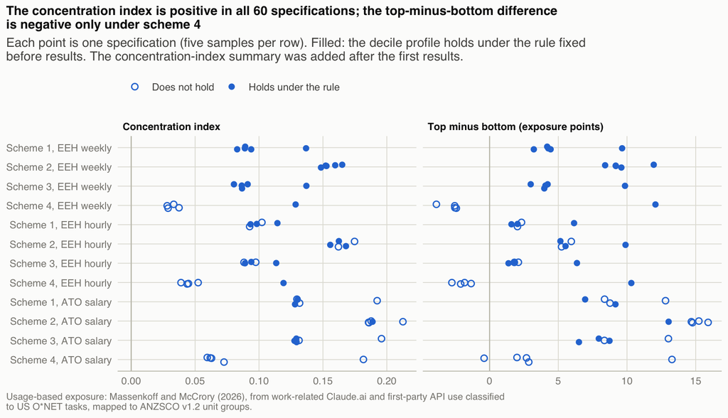

Figure 8: Every specification: concentration index and top-minus-bottom difference.

**Sample restrictions.** Restricting to units fed by four or fewer US occupations steepens the gradient to 9.6 points, mainly by lowering bottom-decile exposure from 0.069 to 0.025; crosswalk smoothing works against the gradient. Excluding units whose US counterparts are mostly unscored (4.4 points), units with imprecise earnings estimates (4.2) or a draft list of owner-operator units (3.2) leaves it close to the main result. The hourly ranking flattens it to 1.6 points. Counting unscored US counterparts as zero, a lower bound, gives 3.9 points, with the peak still in decile 7.

**Single units.** The top-minus-bottom difference depends on a few large units (Figure 9). Under scheme 1, leaving out Sales Assistants (General) raises it to 6.9 points and leaving out Finance Managers lowers it to 2.5; the profile holds under the rule in every such run, and the concentration index stays between 0.079 and 0.098. Under scheme 4, Sales Assistants links only to US Retail Salespersons, whose score is high relative to related occupations. The unit holds 3.9% of employment, mostly in the bottom decile. Leaving it out moves the scheme-4 difference from −2.4 to +7.7 points, and the scheme-4 profile then holds under the rule. The influence check, the unscored-share measure and the sensitivity run built on it were added after the first results.

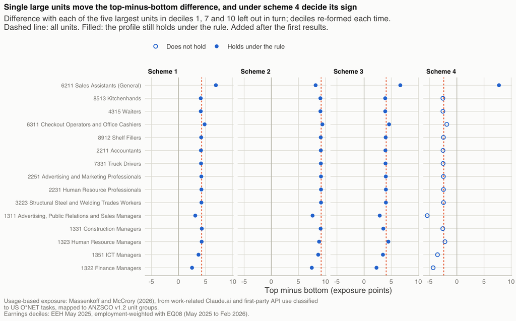

Figure 9: Influence of single large units on the top-minus-bottom difference.

### 5.1 Uncertainty

Every number so far is a point estimate. Three sources of uncertainty that they leave out are simulated (appendix). **Crosswalk weights:** each unit’s scheme-1 weights over its scored US occupations are redrawn from a Dirichlet distribution centred on them, with its concentration chosen so that unit values vary across draws about as much as they vary across schemes 1 to 3; a wider setting cuts the concentration to a quarter. **Earnings:** EEH weekly earnings are redrawn from their published relative standard errors, and ranks and deciles are re-formed in each draw. **Employment** is held fixed, because EQ08 publishes no standard errors. Each setting has 500 draws. Unscored links are bounded rather than simulated.

Table 7: Share of simulated draws in which each headline result holds. Crosswalk: Dirichlet draws of each unit’s US weights. Wider: the same with a quarter of the concentration. Earnings: draws from EEH relative standard errors. Both: crosswalk and earnings together. Added after the first results.

| Result | Crosswalk | Wider | Earnings | Both |
| --- | --- | --- | --- | --- |
| Concentration index positive | 100% | 100% | 100% | 100% |
| Rank concentration index positive | 100% | 100% | 100% | 100% |
| Usage between JSA automation and the capability measures (rank index) | 100% | 100% | 100% | 100% |
| Extensive margin higher in decile 10 than in decile 1 | 100% | 100% | 100% | 100% |
| Top-minus-bottom difference positive | 99% | 92% | 100% | 97% |
| Decile profile holds under the rule | 100% | 97% | 90% | 90% |
| Peak in decile 7 | 97% | 93% | 42% | 41% |
| Intensity lower in decile 10 than in decile 1 | 93% | 72% | 100% | 91% |
| Top-quintile gap against JSA automation positive | 100% | 99% | 100% | 97% |
| Bottom-quintile gap against JSA automation negative | 100% | 100% | 100% | 100% |
| Capability measures: bottom gap positive, top gap negative | 100% | 97% | 100% | 100% |
| Women’s mean above men’s | 100% | 100% | 100% | 100% |
| Women above men in every decile | 98% | 85% | 68% | 64% |
| WA mean below national | 100% | 100% | 100% | 100% |

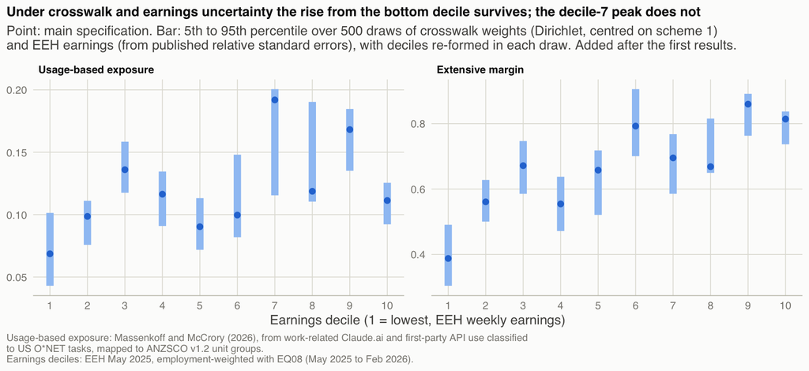

Figure 10: Decile profile with the range over simulated crosswalk weights and earnings.

The concentration index and the rank index are positive in every draw under every setting (Table 7); with both sources of uncertainty, the rank index lies between 0.058 and 0.084 (5th to 95th percentile), and usage sits between JSA automation and the capability measures in every draw. The extensive margin is higher at the top than at the bottom in every draw, and women’s mean exposure is above men’s in every draw. Results tied to single deciles are less stable. The top-minus-bottom difference is positive in 97% of draws, ranging from 0.3 to 7.0 points; women are above men in every single decile in 64%; and the peak stays in decile 7 in only 41% (Figure 10). The peak is the most fragile feature of the profile. Of the 15 largest disagreements with JSA automation, 9 stay among the 15 largest in at least 90 per cent of draws.

Unscored US counterparts are most common in deciles 3 and 2 (up to 28% of linked US employment). Counting them as zero gives a top-minus-bottom difference of 3.9 points and a concentration index of 0.078. Counting them as one, a score no published occupation reaches (the highest is 0.745), raises those deciles most: the difference becomes 10.0 points, but the concentration index falls to 0.010, the peak moves to decile 3, and the rank index stays positive at 0.041.

### 5.2 Another platform

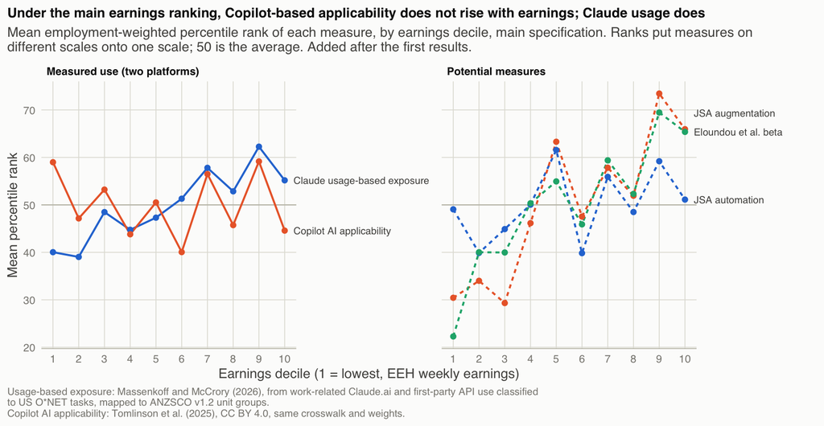

Figure 11: Mean percentile rank of each measure by earnings decile, Claude usage, Copilot applicability and the potential measures.

Claude’s users are self-selected, and platform choice shapes what logs show (Yin and Ogut 2026). As a check, Microsoft’s AI applicability score (Tomlinson et al. 2025), built from Copilot conversations classified to work activities, goes through the same crosswalk, weights, rankings and samples as the usage-based score. The score combines how much of an occupation’s work activities the conversations cover, how often they succeed and how much of each activity they do. It shares no data with Claude usage, and across units the two are positively rank-correlated: 0.65 in the main specification and between 0.60 and 0.73 across specifications. But Copilot applicability is not concentrated among higher earners under the main ranking. Its rank index is −0.011 and its rank correlation with earnings −0.03, against 0.073 and 0.22 for Claude usage (Figure 11). Across specifications its rank index is positive in 48 of 60: 8 of 20 under EEH weekly earnings, and all 40 under the hourly and ATO rankings. A two-platform composite, the mean of each unit’s two percentile ranks, is positive in all 60 (0.015 to 0.107; 0.033 in the main specification).

The two measures differ in construct as well as platform, so the comparison cannot say how much of the difference comes from who uses each platform and how much from how each measure is built. It does show that the concentration among higher earners is weaker, and depends on the earnings ranking, when usage comes from another platform.

## 6 A framework for reading the results: AI in a two-capital model

This section reads the results through the two-capital model of the skill premium in Section 3 of the author’s honours thesis (Taya 2026), which builds on the capital-skill complementarity framework of Krusell et al. (2000). It is a reading, not a test; the derivations are checked symbolically and numerically in `theory/check_theory.py`.

Output is a nested CES in which machinery $K^M$ combines with unskilled labour $U$ and ICT capital $K^I$ with skilled labour $S$:
$$Y=\left[\omega V^{\rho}+(1-\omega)X^{\rho}\right]^{1/\rho},$$
$$V=\left[\lambda U^{\eta_V}+(1-\lambda)(K^M)^{\eta_V}\right]^{1/\eta_V},\qquad X=\left[\mu S^{\eta_X}+(1-\mu)(K^I)^{\eta_X}\right]^{1/\eta_X},$$
with $U=A^UN^U$, $S=A^SN^S$, $\sigma_{VX}=1/(1-\rho)$, $\sigma_{VU}=1/(1-\eta_V)$ and $\sigma_{XS}=1/(1-\eta_X)$. With competitive wages and technology held fixed, the skill premium $\pi$ responds to the two capital goods as
$$\frac{\partial\ln\pi}{\partial\ln K^I}=s_I\left(\frac{1}{\sigma_{XS}}-\frac{1}{\sigma_{VX}}\right),\qquad\frac{\partial\ln\pi}{\partial\ln K^M}=s_M\left(\frac{1}{\sigma_{VX}}-\frac{1}{\sigma_{VU}}\right),$$
where $s_I$ and $s_M$ are capital’s cost shares within each branch. The thesis calibrates the elasticities using cost shares, from a cross-country panel of 24 countries that does not include Australia: $\sigma_{VX}=$ 2.21, $\sigma_{XS}=$ 0.94 and $\sigma_{VU}=$ 1.56. They are imported here, not Australian estimates. With them, the brackets are +0.61 and −0.19: ICT is a relative complement of skilled labour and machinery of unskilled labour.

Let AI capital $K^A$ enter either as skill-complementing capital, $K^I\to K^I+\zeta K^A$ (scenario C), or as a substitute for skilled labour, $S\to A^SN^S+\psi K^A$ (scenario D), with technology and other inputs fixed. Then
$$\text{C: }\frac{\partial\ln\pi}{\partial\ln K^A}=\frac{\zeta K^A}{K^I+\zeta K^A}\,s_I\left(\frac{1}{\sigma_{XS}}-\frac{1}{\sigma_{VX}}\right),\qquad \text{D: }\frac{\partial\ln\pi}{\partial\ln K^A}=-\frac{\psi K^A}{S}\left(\frac{s_S}{\sigma_{VX}}+\frac{1-s_S}{\sigma_{XS}}\right)<0,$$
with $s_S=1-s_I$. The scenario C response is positive if and only if $\sigma_{XS}<\sigma_{VX}$, which the thesis’s elasticities satisfy. If AI enters both ways the two responses add, and the sign depends on $\zeta$, $\psi$ and the branch shares. If AI instead performs unskilled tasks, the premium rises.

**What the evidence can speak to.** Both scenarios place AI’s use in the skilled branch. The positive concentration index and the rising extensive margin fit that location better than an unskilled-task channel. Three features qualify the reading. Use peaks in decile 7, not at the top, and the peak is fragile (Section 5.1), so mapping high-earning occupations onto the skilled branch is loose. Across occupations, measured use follows teleworkability more closely than earnings (Section 4.4): it sits in occupations whose work runs through a computer, which overlap with the skilled branch but are not the same thing. And the one available measure of how AI is used, the share of global Claude.ai conversations classed as automation, lies between 47 and 55 per cent in every decile with no gradient (appendix). As far as the Economic Index classifies it, the mode of use does not vary with earnings.

**What it cannot.** The data cannot separate scenario C from D, because both place use in the same occupations. The automation label describes conversation patterns, not substitution in production, and nothing here observes AI capital, its price or wages, so the sign of the combined response is not determined. Within-occupation task evidence could help. The tasks Anthropic observes in its data have higher estimated schooling requirements than the average task (14.4 against 13.2 years), so covering them would on average deskill jobs (Appel et al. 2026); in Autor and Thompson’s (2025) framework, automating an occupation’s expert tasks lowers its wages and raises its employment, which would sit closer to scenario D. The evidence restricts where AI is used; it does not tell us what AI does to the skill premium.

## 7 Limitations

**One provider and its users.** Claude.ai and Anthropic’s API serve a self-selected group; JSA reports that Claude.ai has under three per cent of Australian market share (Jobs and Skills Australia 2025, 36), without a source. Usage-based scores combine how applicable AI is to a task with who uses the platform: varying only the platform input changes estimated employment effects by a factor of 1.9 (Yin and Ogut 2026), and Tomlinson et al. (2025) find Copilot-based applicability only weakly correlated with US occupational wages (an employment-weighted correlation of 0.13). Part of the earnings gradient here could be specific to Claude’s user base, and the Copilot comparison in Section 5.2 supports that concern: mapped the same way, Copilot-based applicability is not concentrated among higher earners under the main ranking.

**Tasks, not jobs.** The source classifies the task in each conversation, not the job of the person having it; the Australian rows in Section 4.8 carry the same caveat.

**Zeros, gates and vintages.** Over half of scored US occupations are exactly zero. A zero can mean the tasks fell below the usage gate or that used tasks failed the capability gate. Detailed rankings change between Anthropic data vintages while broad structure is stable (Levkoff 2026). Rebuilding the scores from published task data with O*NET task weights reaches a rank correlation of 0.87, and 0.82 among occupations with a positive score.

**US tasks applied to Australian occupations.** The primary chain passes through ISCO-08, coarser than either end; units fed by five or more US occupations hold 38.5% of employment. The ABS correspondence includes partial matches that attach small weights to unrelated occupations, such as beauty and teller occupations for general sales assistants. Task content differs across countries within the same occupation (Lewandowski et al. 2022). Some source scores are anomalous relative to related occupations: Legal Secretaries and Administrative Assistants score zero while Paralegals score positive, Bartenders score zero, and Retail Salespersons score higher than Lawyers. Whether these are artefacts or signal is not settled; large clerical and sales occupations carry much of US employment-weighted exposure (Levkoff 2026). They pass through the crosswalk unchanged.

**Earnings.** Weekly earnings mix hourly pay with hours worked, and no hourly earnings are published at unit-group level. EEH leaves out owner-managers, whom EQ08 counts; the owner-operator exclusion uses a judgement list, because ABS publishes form of employment only by major group (Australian Bureau of Statistics 2025). Nineteen units take their minor group’s mean, and 25 units have relative standard errors above 25 per cent. In the ATO data, 23.1% of individuals have a blank or unclassifiable occupation.

**Teleworkability.** Dingel and Neiman’s classification describes US O*NET occupations, predates generative AI and reaches Australian units through the same crosswalk as the usage scores. Its repository carries a software licence (GPL-3.0), so it is used only in aggregate statistics.

**Sampling error and timing.** EQ08 publishes no standard errors, so the simulations in Section 5.1 hold employment fixed; unit-level employment, especially in WA, is estimated with error not shown here. The earnings draws treat units as independent. The sources cover different periods (Table 8). The published SOC major-group usage shares do not sum to one hundred per cent for any geography, and the documentation does not say what fills the gap.

Table 8: Reference periods.

| Source | Period |
| --- | --- |
| Usage-based scores | Anthropic samples, August and November 2025 |
| Australian usage shares | April and May 2026 |
| Employment | May 2025 to February 2026 |
| Earnings | May 2025 (EEH) and 2023–24 (ATO) |

## 8 Conclusion

Measured AI use, as Claude’s logs record it, is concentrated in higher-earning Australian occupations, but less so than capability measures imply. Within these data the concentration is robust to every specification and to simulated crosswalk and earnings uncertainty; the shape of the profile, its decile-7 peak and its bottom-to-top difference are not. The gradient runs through whether any of an occupation’s tasks show use at all. Two checks limit how far it can be read as a gradient in pay. Across occupations it all but disappears once teleworkability is held fixed, and a Copilot-based measure mapped the same way is not concentrated among higher earners under the main ranking.

For monitoring, the results argue for pairing usage-based and potential measures. Measured use is more concentrated among high earners than JSA’s automation potential, and usage-based scores rank clerical occupations low, including those where Australian hiring has weakened most. Neither kind of measure alone locates AI’s labour-market footprint.

Three steps would most improve the evidence: usage data that separate platforms and their surfaces, so the platform question can be answered rather than flagged; usage built on Australian occupations’ own task lists, so the ISCO-08 step no longer smooths the scores; and linking usage-based exposure to Australian outcomes, as DEWR’s framework does for potential exposure. The last step now requires a bridge to OSCA, because EQ08 has ended.

## Provenance, changes and disclosure

**Provenance.** The main specification and the holding rules were recorded in `decision_log.md` before any results were produced; the repository’s history begins after the first results, so this ordering rests on the log, not on the commit history. The research question, framing, key findings and Section 6 were written after the first results. A planned file of research questions and choices was dropped.

**What did not work.** Hourly earnings, the intended primary ranking, are not published at unit-group level. ABS standard tables give form of employment only by major group, so the owner-operator run uses a judgement list. The level concentration index is not defined for AIOE, which takes negative values; only its rank index is reported. The JSA correspondence proved to be coded to ANZSCO v1.2, not v1.3 as its archived page implied. Rebuilding the published scores from task data reached a rank correlation of 0.87 against a target of 0.9. Scheme 4 does not reproduce the main profile, and the bottom-quintile gap against JSA automation does not keep its sign across schemes.

**Added after the first results.** The influence check, the unscored-share measure and the sensitivity run built on it; and, after review of the first draft, the rank and Erreygers indices, the lower bound for unscored links, gaps without zero units, the normalised WA contributions, the decomposition of the women-men gap and the smoothed profile. Each is labelled where it appears.

**Added for this version (v1.0).** The comparison with Copilot-based applicability, the simulations of crosswalk and earnings uncertainty with bounds for unscored links, and the regressions with teleworkability. All three were proposed in the review of the first draft; their designs are recorded in `decision_log.md` (note N22).

**Disclosure.** No funding. The usage data are from Anthropic’s public Economic Index releases; Anthropic had no role in this note and has not reviewed or endorsed it.

**Credits.** This note includes information from the O*NET 31.0 Database by the U.S. Department of Labor, Employment and Training Administration (USDOL/ETA). Used under the CC BY 4.0 license. O*NET® is a trademark of USDOL/ETA. Luc Taya has modified all or some of this information. USDOL/ETA has not approved, endorsed, or tested these modifications. Australian Bureau of Statistics data are used under CC BY 4.0; ATO data under CC BY 2.5 AU; Jobs and Skills Australia material is © Commonwealth of Australia, used under CC BY 4.0. Full credits and licences are in `docs/credits.md`.

## References

Appel, Ruth, Maxim Massenkoff, Peter McCrory, et al. 2026. “Anthropic Economic Index Report: Economic Primitives.” Anthropic, January 15. https://www.anthropic.com/research/anthropic-economic-index-january-2026-report.

Australian Bureau of Statistics. 2025. “Working Arrangements, August 2025.” December 12. https://www.abs.gov.au/statistics/labour/earnings-and-working-conditions/working-arrangements/latest-release.

Australian Bureau of Statistics. 2026a. “Employee Earnings and Hours, Australia, May 2025.” January 23. https://www.abs.gov.au/statistics/labour/earnings-and-working-conditions/employee-earnings-and-hours-australia/may-2025.

Australian Bureau of Statistics. 2026b. “Labour Force, Australia, Detailed, March 2026, Table EQ08.” March 26. https://www.abs.gov.au/statistics/labour/employment-and-unemployment/labour-force-australia-detailed/mar-2026.

Australian Bureau of Statistics. 2026c. “Labour Force, Australia Methodology, September 2026.” October 15. https://www.abs.gov.au/methodologies/labour-force-australia-methodology/sep-2026.

Australian Bureau of Statistics. 2026d. “Upcoming Changes to Labour Force Survey Outputs.” March 19. https://www.abs.gov.au/statistics/detailed-methodology-information/information-papers/upcoming-changes-labour-force-survey-outputs.

Australian Taxation Office. n.d. “Taxation Statistics 2023–24: Individuals, Table 15.” Data.gov.au. https://data.gov.au/data/dataset/taxation-statistics-2023-24.

Autor, D., and N. Thompson. 2025. *Expertise*. NBER Working Paper No. 33941. National Bureau of Economic Research.

Borland, Jeff, and Michael Coelli. 2017. “Are Robots Taking Our Jobs?” *Australian Economic Review* 50 (4): 377–97.

Cazzaniga, M., F. Jaumotte, L. Li, et al. 2024. *Gen-AI: Artificial Intelligence and the Future of Work*. IMF Staff Discussion Note SDN/2024/001. International Monetary Fund.

Chatterji, A., T. Cunningham, D. Deming, et al. 2025. *How People Use ChatGPT*. NBER Working Paper No. 34255. National Bureau of Economic Research.

Coelli, Michael, and Jeff Borland. 2016. “Job Polarisation and Earnings Inequality in Australia.” *Economic Record* 92 (296): 1–27.

Demirev, Georgi. 2026. “AI and the Composition of Labor Demand: Evidence from Online Job Postings.” September 9. https://ssrn.com/abstract=7054839.

Department of Employment and Workplace Relations. 2026. *AI and Employment in Australia: Monitoring Framework and Evidence to Date*. Department of Employment; Workplace Relations. https://www.dewr.gov.au/download/17666/ai-and-employment-australia/43205/ai-and-employment-australia/pdf.

Dingel, Jonathan I., and Brent Neiman. 2020. “How Many Jobs Can Be Done at Home?” *Journal of Public Economics* 189: 104235. https://doi.org/10.1016/j.jpubeco.2020.104235.

Eloundou, Tyna, Sam Manning, Pamela Mishkin, and Daniel Rock. 2024. “GPTs Are GPTs: Labor Market Impact Potential of LLMs.” *Science* 384: 1306–8.

Erreygers, G. 2009. “Correcting the Concentration Index.” *Journal of Health Economics* 28 (2): 504–15.

Felten, Edward, Manav Raj, and Robert Seamans. 2021. “Occupational, Industry, and Geographic Exposure to Artificial Intelligence: A Novel Dataset and Its Potential Uses.” *Strategic Management Journal* 42 (12): 2195–217.

Gelbach, Jonah B. 2016. “When Do Covariates Matter? And Which Ones, and How Much?” *Journal of Labor Economics* 34 (2): 509–43. https://doi.org/10.1086/683668.

Gillen, Ben, Erik Snowberg, and Leeat Yariv. 2019. “Experimenting with Measurement Error: Techniques with Applications to the Caltech Cohort Study.” *Journal of Political Economy* 127 (4): 1826–63. https://doi.org/10.1086/701681.

Gmyrek, P., J. Berg, and D. Bescond. 2023. *Generative AI and Jobs: A Global Analysis of Potential Effects on Job Quantity and Quality*. ILO Working Paper No. 96. International Labour Organization. https://doi.org/10.54394/FHEM8239.

Gmyrek, P., J. Berg, K. Kamiński, et al. 2025. *Generative AI and Jobs: A Refined Global Index of Occupational Exposure*. ILO Working Paper No. 140. International Labour Organization. https://doi.org/10.54394/HETP0387.

Gross, Zac. 2026. “Kookaburras in the Coal Mine?” *Gross National Product (Substack)*, June 2. https://gross.substack.com/p/kookaburras-in-the-coal-mine.

Handa, Kunal, Alex Tamkin, Miles McCain, et al. 2025. “Which Economic Tasks Are Performed with AI? Evidence from Millions of Claude Conversations.” *arXiv*, no. 2503.04761. https://arxiv.org/abs/2503.04761.

Humlum, A., and E. Vestergaard. 2025. “The Unequal Adoption of ChatGPT Exacerbates Existing Inequalities Among Workers.” *Proceedings of the National Academy of Sciences* 122 (1): e2414972121.

Jobs and Skills Australia. 2024. “ANZSCO 2013 Version 1.2 to O*NET-SOC 2019 Taxonomy Correspondence.” Labour Market Insights (archived copy), March 15. https://web.archive.org/web/20240315061455/https://labourmarketinsights.gov.au/media/pmukn3qt/anzsco-2013-to-onet-soc-2019.xlsx.

Jobs and Skills Australia. 2025. *Our Gen AI Transition: Implications for Work and Skills*. Jobs; Skills Australia. https://www.jobsandskills.gov.au/download/19803/our-gen-ai-transition-implications-work-and-skills/3364/our-gen-ai-transition/pdf.

Krusell, Per, Lee E. Ohanian, José-Víctor Ríos-Rull, and Giovanni L. Violante. 2000. “Capital-Skill Complementarity and Inequality: A Macroeconomic Analysis.” *Econometrica* 68 (5): 1029–53.

Levkoff, Steven B. 2026. *Artificially Intelligent? Predicted Capability Versus Observed Adoption in US Occupations*. SSRN Working Paper No. 7217958. https://ssrn.com/abstract=7217958.

Lewandowski, P., A. Park, W. Hardy, Y. Du, and S. Wu. 2022. “Technology, Skills, and Globalization: Explaining International Differences in Routine and Nonroutine Work Using Survey Data.” *World Bank Economic Review* 36 (3): 687–708.

Massenkoff, Maxim, Eva Lyubich, Szymon Sacher, et al. 2026. “Anthropic Economic Index Report: Cadences.” June 26. https://www.anthropic.com/research/economic-index-june-2026-report.

Massenkoff, Maxim, and Peter McCrory. 2026. “Labor Market Impacts of AI: A New Measure and Early Evidence.” Anthropic, March 5. https://www.anthropic.com/research/labor-market-impacts.

McCrory, Peter. 2026. “How Australia Uses Claude: Findings from the Anthropic Economic Index.” Anthropic, March 31. https://www.anthropic.com/research/how-australia-uses-claude.

Murugan, A., T. Aguirre, A. Nagaraj, and R. Bommasani. 2026. “The Jagged Global Economy: Frontier AI Unevenly Exposes National Economies.” *arXiv*, no. 2607.05404. https://arxiv.org/abs/2607.05404.

Nolan, Matt, and Ewan Rankin. 2026. “Taxing Robots: The Good News and Risks about AI and Government Revenue.” e61 Institute, August 7. https://e61.in/taxing-robots-the-good-news-and-risks-about-ai-and-government-revenue/.

Oaxaca, R., and M. Ransom. 1999. “Identification in Detailed Wage Decompositions.” *Review of Economics and Statistics* 81 (1): 154–57.

Pizzinelli, C., A. Panton, M. Mendes Tavares, M. Cazzaniga, and L. Li. 2023. *Labor Market Exposure to AI: Cross-Country Differences and Distributional Implications*. IMF Working Paper WP/23/216. International Monetary Fund.

Taya, Luc. 2026. “Does All Capital Favour Skill? ICT, Machinery and the Skill Premium.” Bachelor of Commerce (Honours) thesis, University of Western Australia.

Tomlinson, Kiran, Sonia Jaffe, Will Wang, Scott Counts, and Siddharth Suri. 2025. “Working with AI: Measuring the Applicability of Generative AI to Occupations.” *arXiv*, no. 2507.07935. https://arxiv.org/abs/2507.07935.

U.S. Bureau of Labor Statistics. n.d. “Occupational Employment and Wage Statistics, May 2025, National.” https://www.bls.gov/oes/.

Webb, M. 2020. *The Impact of Artificial Intelligence on the Labor Market*. Working paper. Stanford University. https://www.michaelwebb.co/webb_ai.pdf.

Yin, Michelle, and Burhan Ogut. 2026. “Who Uses AI? Platform Selection and the Measurement of Occupational AI Exposure.” *arXiv*, no. 2605.21743. https://arxiv.org/abs/2605.21743.

Yun, M.-S. 2005. “A Simple Solution to the Identification Problem in Detailed Wage Decompositions.” *Economic Inquiry* 43 (4): 766–72.